# sentiment

## Анализ мнений и оценок (Sentiment analysis)

Попробуем проанализировать эмоциональную окраску (оценку, sentiment) отзывов про отели. Для этого будем использовать словарь оценочной лексики Четверкина.

```r
sentdict <- read.table("~/shared/minor2_2017/2-tm/lab02_tf_idf/sentdict.txt", header=T, stringsAsFactors=F) # словарь оценочной лексики

head(sentdict)
```

```
##         words value
## 1 бесподобный 0.963
## 2   невнятный 0.953
## 3 отличнейший 0.935
## 4  обалденный 0.933
## 5     безумно 0.924
## 6   непонятно 0.921
```

```r
tail(sentdict)
```

```
##                words value
## 4995    бессердечный 0.145
## 4996 присматриваться 0.145
## 4997        крикнуть 0.145
## 4998          богато 0.144
## 4999       скрипучий 0.144
## 5000    режиссерский 0.144
```

Так, для каждого отзыва мы можем посчитать, насколько оценочный характер он носит – без привязки к характеру (позитивный или негативный).

```r
library(tidyverse)
library(tidytext)
reviews <- read_csv("~/shared/minor2_2017/2-tm/lab02_tf_idf/reviews.csv")
reviews.tidy = reviews %>%
  select(id, lem) %>%
  unnest_tokens(words, lem)

rustopwords <- data.frame(words=stopwords::stopwords("ru"), stringsAsFactors=FALSE)
# словарь со стоп-словами

reviews.tidy = reviews.tidy %>%
  anti_join(rustopwords)
reviews.sent = reviews.tidy %>%
  inner_join(sentdict) #почему используется inner_join, а не anti_join?
reviews.sent_count = reviews.sent %>%
  group_by(id) %>%
  summarise(mean = mean(value)) #посчитаем

reviews.sent_count %>% arrange(-mean) %>% head() # самые оценочные отзывы
```

```
## # A tibble: 6 x 2
##   id           mean
##   <chr>       <dbl>
## 1 rn199965111 0.701
## 2 rn213707162 0.682
## 3 rn275836751 0.679
## 4 rn124916246 0.674
## 5 rn120318127 0.672
## 6 rn360409387 0.649
```

```r
reviews$review[reviews$id == "rn280308837"]
```

```
## [1] "\nЖили там три дня. Вид с балкона...без слов. Номер шикарный! Обслуживание супер. Бар на крыше бесподобен, но дорогой, конечно,надо думать)) На завтраки ни разу не успели.\nПо поводу минусов, есть комплиментари Порш,но за три просьбы о поездке,всегда был недоступен водитель,хотя машина стоял…
```

```r
reviews.sent_count %>% arrange(mean) %>% head() # самые нейтральные отзывы
```

```
## # A tibble: 6 x 2
##   id           mean
##   <chr>       <dbl>
## 1 rn263985915 0.177
## 2 rn302404940 0.184
## 3 rn214219506 0.190
## 4 rn287328976 0.193
## 5 rn130004163 0.195
## 6 rn258950968 0.196
```

```r
reviews$review[reviews$id == "rn219370699"]
```

```
## [1] "\nЕщё недавно был Коринтия – Невский Палас, теперь почему-то в названии осталась одна Коринтия.\nНа Невском проспекте, и от Московского вокзала пешком дойти легко, и метро близко, и погулять приятно.\nЖила в этом отеле два раза, один раз был Junior Suite, второй – Superior King Twin( хотя, п…
```

Теперь мы можем попытаться создать свой специфичный для наших данных сентимент-словарь.

Возьмем за отрицательные отзывы все те, кто оценил отель на 1-2 балла, а положительные – на 5. Посмотрим распределение оценок посетителей

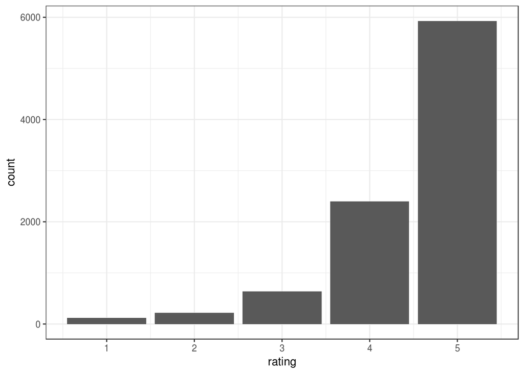

```r
reviews %>% ggplot() + geom_bar(aes(rating)) + theme_bw()
```

```r
positive = reviews.sent %>% filter(id %in% reviews$id[reviews$rating==5]) %>% mutate(sent = "positive")
#можно дополнительно отфильтровать по полезности отзыва (stars == 5)

negative = reviews.sent %>% filter(id %in% reviews$id[reviews$rating<3]) %>% mutate(sent = "negative")

reviews.pmi = rbind(positive, negative) %>% dplyr::select(-id,-value)
reviews.pmi = reviews.pmi %>% dplyr::count(words, sent) %>% spread(sent, n, fill = 0)
```

## Pointwise Mutual Information (PMI)

Отберем оценочные слова из словаря Четверкина, характерные для каждого из классов с помощью PMI.

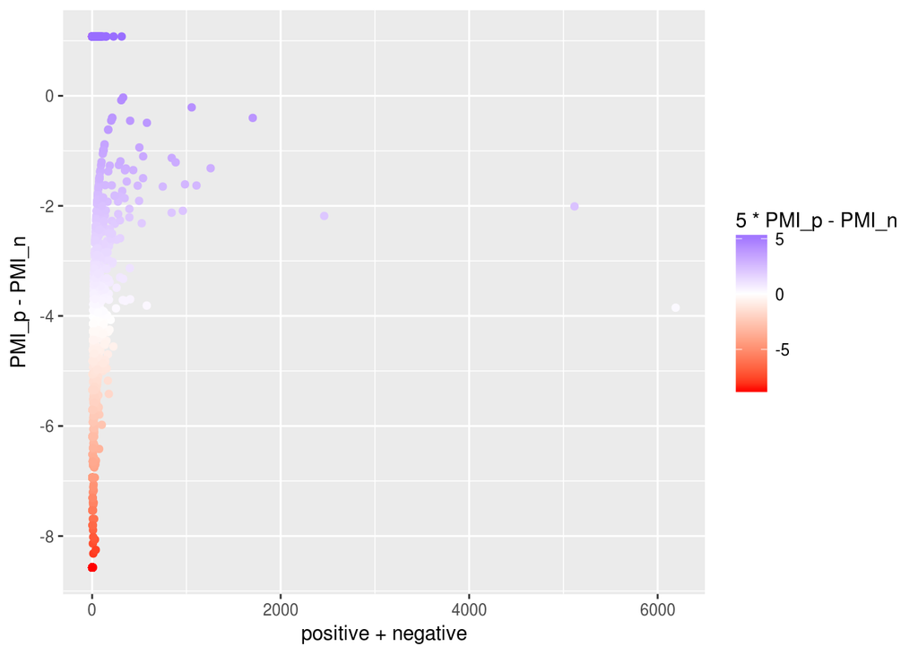

```r
freq_p = reviews.pmi$positive
freq_n = reviews.pmi$negative
sum_p = sum(reviews.pmi$positive)
sum_n = sum(reviews.pmi$negative)

pmi_p = log((freq_p/sum_p)/((freq_p+freq_n)/(sum_p+sum_n)*sum_p/(sum_p+sum_n))+1, base=2)
reviews.pmi$PMI_p = pmi_p

pmi_n = log((freq_n/sum_n)/((freq_p+freq_n)/(sum_p+sum_n)*sum_n/(sum_p+sum_n))+1, base=2)
reviews.pmi$PMI_n = pmi_n

reviews.pmi %>%
  ggplot(aes(x=positive+negative, y=PMI_p-PMI_n, color=5*PMI_p-PMI_n, label=words)) +
  scale_color_gradient2(low="red", high="blue") +
  geom_point()
```

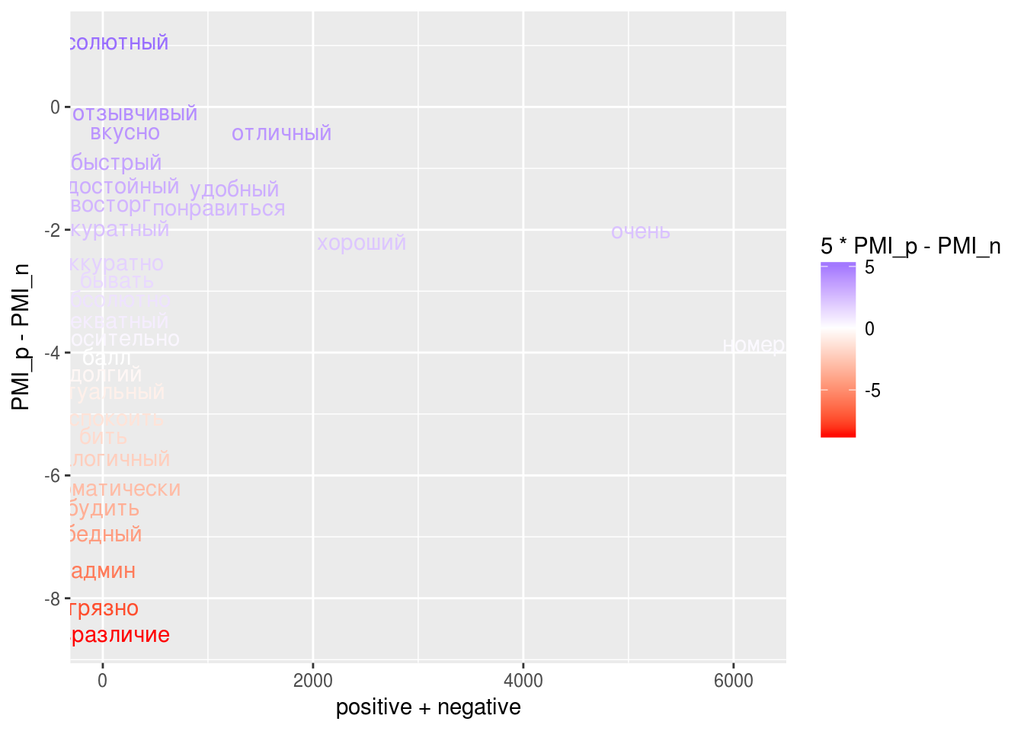

```r
reviews.pmi %>%
  ggplot(aes(x=positive+negative, y=PMI_p-PMI_n, color=5*PMI_p-PMI_n, label=words)) +
  scale_color_gradient2(low="red", high="blue") +
  geom_text(check_overlap = TRUE)
```

## Dunning log-likelihood (G2)

```r
g2 = function(a, b) {
  c = sum(a)
  d = sum(b)
  E1 = c * ((a + b) / (c + d))
  E2 = d * ((a + b) / (c + d))
  return(2*((a*log(a/E1+1e-7)) + (b*log(b/E2+1e-7))))
}

reviews.pmi <- reviews.pmi %>%
  mutate(g2=g2(positive, negative))
```

Посмотрим на соотношения частотности, PMI и G2:

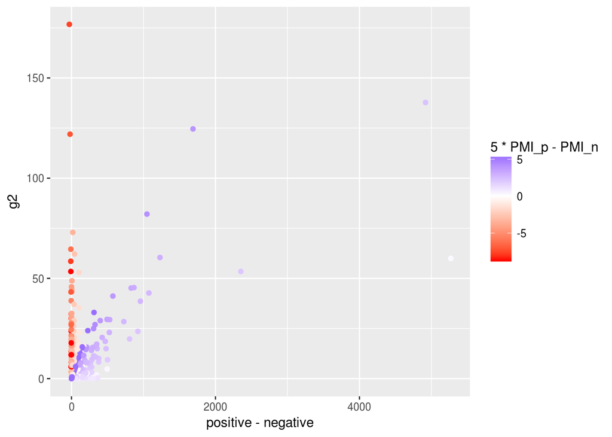

```r
reviews.pmi %>%
  ggplot(aes(x=positive-negative, y=g2, color=5*PMI_p-PMI_n, label=words)) +
  scale_color_gradient2(low="red", high="blue") +
  geom_point()
```

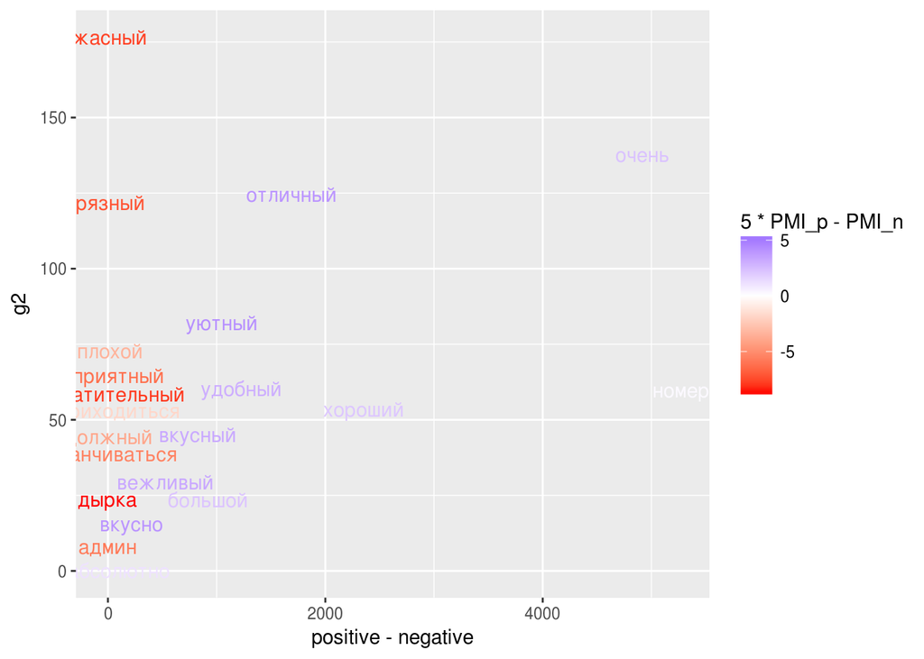

```r
reviews.pmi %>%
  filter(PMI_p>0.5 | PMI_n>0.5) %>%
  ggplot(aes(x=positive-negative, y=g2, color=5*PMI_p-PMI_n, label=words)) +
  scale_color_gradient2(low="red", high="blue") +
  geom_text(check_overlap=TRUE)
```

**Задание**

1. При построении оценочного словаря для нашей базы отзывов мы использовали только отзывы с оценками 1-2 и 5. Теперь ваша задача — пользуясь этим словарем вычислить степень положительного/отрицательного сентимента для всех отзывов из базы с оценками 3-4. Подсказка: используйте PMI_p и PMI_n в качестве меры оценочности. Постройте диаграмму рассеяния (scatterplot) с распределением этих отзывов по степени оценочности.

2(*). Оцените, какие слова наиболее специфичны для отрицательных (1-2) и положительных (5) отзывов, не ограничиваяюсь только лексикой из словаря Четверкина, а учитывая полные тексты отзывов. Постройте облака слов и диаграмму рассеяния, иллюстрирующую, какие слова характерны для каждого класса отзывов.